# homework_week_06_weekend

```r
library(infer)
library(janitor)
library(tidyverse)
```

Explore the dataset and familiarise yourself with it.

```r
data(msleep)
```

```r
glimpse(msleep)
```

```
Rows: 83
Columns: 11
$ name         <chr> "Cheetah", "Owl monkey", "Mountain beaver", "Greater short-tailed shrew", "Cow", "Three-t…
$ genus        <chr> "Acinonyx", "Aotus", "Aplodontia", "Blarina", "Bos", "Bradypus", "Callorhinus", "Calomys"…
$ vore         <chr> "carni", "omni", "herbi", "omni", "herbi", "herbi", "carni", NA, "carni", "herbi", "herbi…
$ order        <chr> "Carnivora", "Primates", "Rodentia", "Soricomorpha", "Artiodactyla", "Pilosa", "Carnivora…
$ conservation <chr> "lc", NA, "nt", "lc", "domesticated", NA, "vu", NA, "domesticated", "lc", "lc", "domestic…
$ sleep_total  <dbl> 12.1, 17.0, 14.4, 14.9, 4.0, 14.4, 8.7, 7.0, 10.1, 3.0, 5.3, 9.4, 10.0, 12.5, 10.3, 8.3, …
$ sleep_rem    <dbl> NA, 1.8, 2.4, 2.3, 0.7, 2.2, 1.4, NA, 2.9, NA, 0.6, 0.8, 0.7, 1.5, 2.2, 2.0, 1.4, 3.1, 0.…
$ sleep_cycle  <dbl> NA, NA, NA, 0.1333333, 0.6666667, 0.7666667, 0.3833333, NA, 0.3333333, NA, NA, 0.2166667,…
$ awake        <dbl> 11.90, 7.00, 9.60, 9.10, 20.00, 9.60, 15.30, 17.00, 13.90, 21.00, 18.70, 14.60, 14.00, 11…
$ brainwt      <dbl> NA, 0.01550, NA, 0.00029, 0.42300, NA, NA, NA, 0.07000, 0.09820, 0.11500, 0.00550, NA, 0.…
$ bodywt       <dbl> 50.000, 0.480, 1.350, 0.019, 600.000, 3.850, 20.490, 0.045, 14.000, 14.800, 33.500, 0.728…
```

1. Jabberwockies sleep for around 7 hours a night, on average. Perform an appropriate statistical test to determine whether the mean sleep_total in the sampled population of animal types differs from the typical value for jabberwockies.

H0: the mean sleep_total for sampled population is the same as the mean sleep_total for jabberwockies Ha: the mean sleep_total for sampled population is different from the mean sleep_total for jabberwockies

H0: population mean_sleep_total = 7 Ha: population_mean_sleep_total != 7

α=0.05

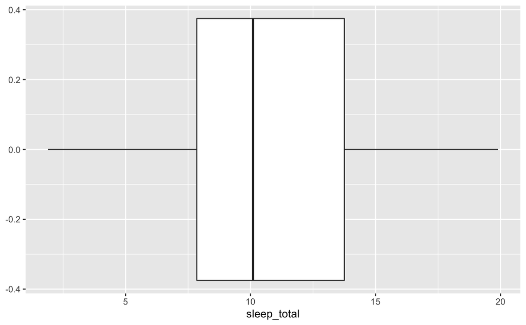

```r
msleep %>%
  ggplot(aes(y = sleep_total)) +
  geom_boxplot() +
  coord_flip()
```

```r
observed_stat <- msleep %>%
  summarise(mean_rating = mean(sleep_total))

observed_stat
```

| mean_rating |
| --- |
| 10.43373 |

```r
null_distribution<- msleep %>%
  specify(response = sleep_total) %>%
  hypothesize(null = "point", mu = 7) %>%
  generate(reps = 10000, type = "bootstrap") %>%
  calculate(stat = "mean")
```

[output not shown]

[output cut: 990 more lines]

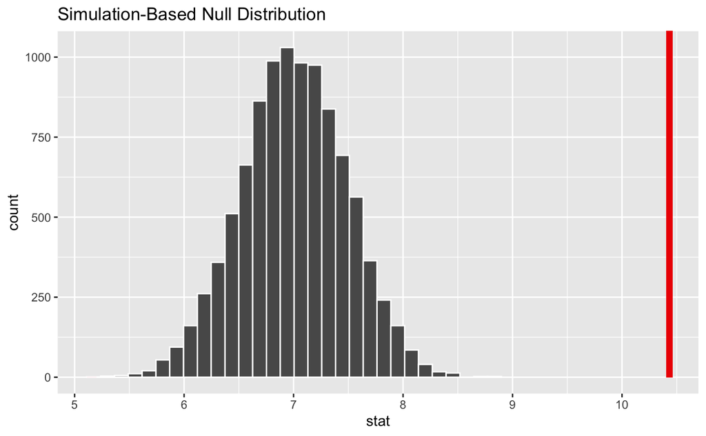

```r
null_distribution %>%
  visualise(bins = 30) +
  shade_p_value(obs_stat = observed_stat$mean_rating, direction = "both")
```

```r
p_value <- null_distribution %>%
  get_p_value(obs_stat = observed_stat$mean_rating, direction = "both")
```

```
Please be cautious in reporting a p-value of 0. This result is an approximation based on the number of `reps` chosen in the `generate()` step. See `?get_p_value()` for more information.
```

```r
p_value
```

| p_value |
| --- |
| 0 |

2. Perform an appropriate statistical test to determine whether omnivores sleep for significantly longer than herbivores, on average.

Assuming the conventional significance level α = 0.05

H0: omni_sleep - herbi_sleep = 0 Ha: omni_sleep - herbi_sleep > 0

```r
diet_msleep <- msleep %>%
  filter(vore %in% c("omni", "herbi"))
```

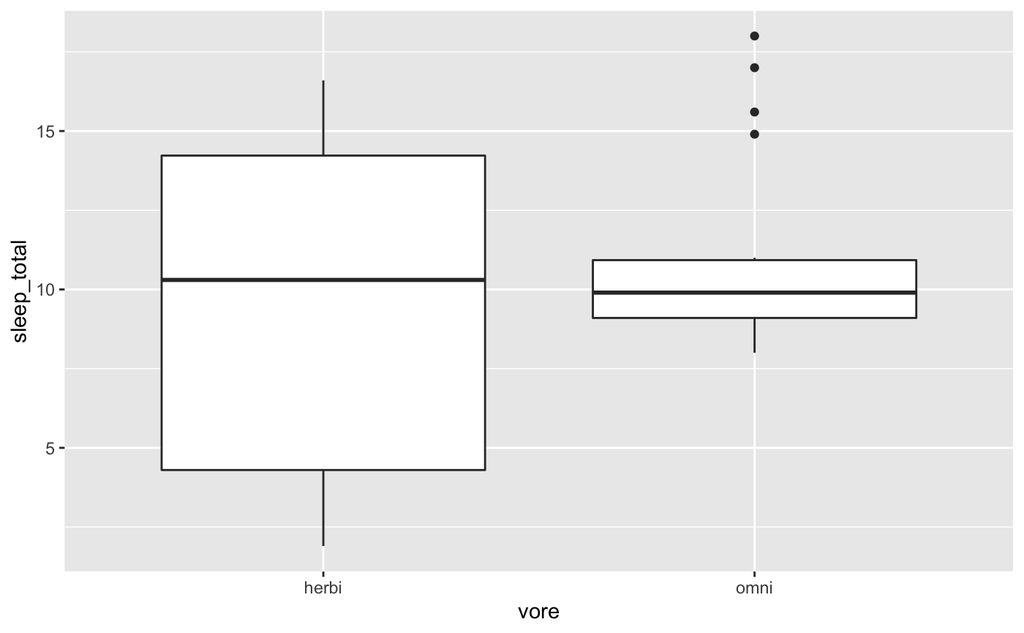

```r
diet_msleep %>%
  ggplot(aes(y = sleep_total, x = vore)) +
  geom_boxplot()
```

[output not shown]

[output cut: 990 more lines]

```r
observed_stat <- diet_msleep %>%
  specify(response = sleep_total, explanatory = vore) %>%
  calculate(stat = "diff in means", order = c("omni", "herbi"))

observed_stat
```

| stat |
| --- |
| 1.415625 |

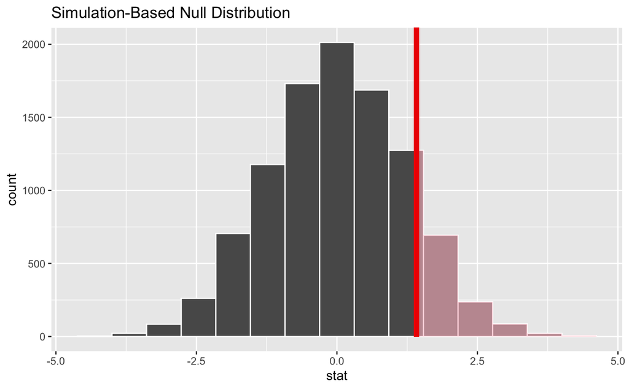

```r
null_distribution_2 %>%
  visualise() +
  shade_p_value(obs_stat = observed_stat, direction = "right")
```

[output not shown]

```r
null_distribution_2 %>%
  get_p_value(obs_stat = observed_stat, direction = "right")
```

| p_value |
| --- |
| 0.1258 |

Perform an appropriate statistical test to determine whether the proportion of domesticated animal types in the population of animal types is greater than 5%. [Hint - think about creating an is_domesticated variable for the analysis]

```r
animals <- msleep %>%
  filter(!is.na(conservation))
```

```r
animals %>%
  group_by(conservation) %>%
  summarise(prop = n()/nrow(animals)) %>%
  filter(conservation == "domesticated")
```

| conservation | prop |
| --- | --- |
| domesticated | 0.1851852 |

```r
animals_domesticated <- msleep %>%
  filter(!is.na(conservation)) %>%
  mutate(is_domesticated = ifelse(conservation == "domesticated", "domesticated", "not_domesticated"))
animals_domesticated
```

| name | genus | vore | order | conservation | sleep_total | sleep_rem | sleep_cycle | awake | brainwt | bodywt | is_domesticated |
| --- | --- | --- | --- | --- | --- | --- | --- | --- | --- | --- | --- |
| Cheetah | Acinonyx | carni | Carnivora | lc | 12.1 | NA | NA | 11.90 | NA | 50.000 | not_domesticated |
| Mountain beaver | Aplodontia | herbi | Rodentia | nt | 14.4 | 2.4 | NA | 9.60 | NA | 1.350 | not_domesticated |
| Greater short-tailed shrew | Blarina | omni | Soricomorpha | lc | 14.9 | 2.3 | 0.1333333 | 9.10 | 0.00029 | 0.019 | not_domesticated |
| Cow | Bos | herbi | Artiodactyla | domesticated | 4.0 | 0.7 | 0.6666667 | 20.00 | 0.42300 | 600.000 | domesticated |
| Northern fur seal | Callorhinus | carni | Carnivora | vu | 8.7 | 1.4 | 0.3833333 | 15.30 | NA | 20.490 | not_domesticated |
| Dog | Canis | carni | Carnivora | domesticated | 10.1 | 2.9 | 0.3333333 | 13.90 | 0.07000 | 14.000 | domesticated |
| Roe deer | Capreolus | herbi | Artiodactyla | lc | 3.0 | NA | NA | 21.00 | 0.09820 | 14.800 | not_domesticated |
| Goat | Capri | herbi | Artiodactyla | lc | 5.3 | 0.6 | NA | 18.70 | 0.11500 | 33.500 | not_domesticated |
| Guinea pig | Cavis | herbi | Rodentia | domesticated | 9.4 | 0.8 | 0.2166667 | 14.60 | 0.00550 | 0.728 | domesticated |
| Grivet | Cercopithecus | omni | Primates | lc | 10.0 | 0.7 | NA | 14.00 | NA | 4.750 | not_domesticated |

[output cut: 44 more lines]

```r
animals_domesticated %>%
  group_by(is_domesticated) %>%
  summarise(prop = n() / nrow(animals_domesticated))
```

| is_domesticated | prop |
| --- | --- |
| domesticated | 0.1851852 |
| not_domesticated | 0.8148148 |

# 1.2.1 Defining the Hypothesis

1. comparing means from two paired samples

H0 : μ0 = 4 Ha : μ0 ≠ 4

H0: Awareness of shop is not changed after flyering. Ha: Awareness of shop is significantly increased after flyering

H0 : H0 is true, i.e. the probability of ‘success’ is set to π 0. Ha: πa

H0: CTR not changed when banner at top of page. Ha: CTR changed significantly after position of banner on top of page

H0 : μ average_width = average_width_sample Ha: μ average_width ≠ average_width_sample

H0: The mean width of part is the same as the mean of the sample Ha: the mean width of the part is different from the mean of the sample

# 1.2.2 Interpreting the results

p-value is less than significance level. So, we reject H0 in favour of Ha.